# Paper analysis

# Introducción

El presente documento corresponde al detalle del análisis de datos del artículo “Socialización de la Meritocracia: El rol de la Familia y la Escuela”, a cargo del investigador Juan Carlos Castillo y enmarcado en el proyecto Fondecyt Regular 1181219. El documento se divide en análisis descriptivos y multivariado. La sección de descriptivos presenta una panorámica de las variables utilizadas en el artículo, tanto a nivel univariado como bivariado. La sección multivariada presenta el análisis a partir de tres técnicas: regresiones lineales multinivel, regresiones logísticas ordinales y regresiones logísticas binarias, generando modelos para ambos indicadores que componen la variable dependiente (esfuerzo y salir adelante). Por último, se termina con una sección de “Otros análisis”, donde se exploran variantes de los análisis presentados, cambiando las codificaciones o introduciendo otras posibles variables relevantes. El análisis aquí presentado queda a disposición de cualquier persona que quiera reproducir, replicar o revisar el proceso del artículo señalado.

# Descriptivos

```r
knitr::opts_chunk$set(warning = FALSE, message = FALSE, cache = TRUE)

if (!require("pacman")) install.packages("pacman")  #si falta pacman, instalar
if (!require("tinytex")) install.packages("tinytex")#si falta tinytex, instalar
```

```r
pacman::p_load(knitr, kableExtra, dplyr, ggplot2,sjmisc,texreg,webshot) # librerias
knitr::opts_chunk$set(warning = FALSE,  # mensaje de warning
                      message = FALSE,  # mensajes/avisos de librerias
                      cache = FALSE,    # cache de los chunks,usar analisis pesados
                      out.width = '85%',# largo de imagen en %
                      fig.pos= "H",     # posicion figuras H = HERE
                      echo = FALSE      # incluir chunk en output
                      )
options(scipen=999) # notacion cientifica
rm(list=ls())       # limpiar workspace
options(knitr.kable.NA = '') # NA en kable = ''


table_format = if(is_html_output()) { # Usar en argumento "format=" de kable
  "html"
} else if(is_latex_output()) {
  "latex"
}

fwidth = if(is_html_output()) { #Usar en argumento "full_width" de kableExtra
  T
} else if(is_latex_output()) {
  F
}

format_size = if(is_html_output()) { # Usar en argumento "format=" de kable
 20
} else if(is_latex_output()) {
  10
}

stars.pval2=function (p.value)
 {
    unclass(symnum(p.value, corr = FALSE, na = FALSE, cutpoints = c(0,
        0.001, 0.01, 0.05, 1), symbols = c("***",
        "**", "*", " ")))
 }

#stars.pval2(0.002)

#gtools::stars.pval
```

## Univariado

| **Label** | **Stats / Values** | **Freqs (% of Valid)** | **Graph** | **Valid** |
| --- | --- | --- | --- | --- |
| Percepción meritocracia: Importancia trabajo duro (estudiantes) | 1. Nada importante 2. Algo importante 3. Importante 4. Muy importante | 16 ( 3.0% ) 60 ( 11.2% ) 149 ( 27.7% ) 312 ( 58.1% ) |  | 537 (100.0%) |
| Percepción meritocracia: Esfuerzo para salir adelante (estudiantes) | 1. Muy en desacuerdo 2. En desacuerdo 3. De acuerdo 4. Muy de acuerdo | 20 ( 3.7% ) 82 ( 15.3% ) 223 ( 41.5% ) 212 ( 39.5% ) |  | 537 (100.0%) |
| Percepción meritocracia: Importancia trabajo duro (apoderado) | 1. Nada importante 2. Algo importante 3. Importante 4. Muy importante | 35 ( 6.5% ) 64 ( 11.9% ) 169 ( 31.5% ) 269 ( 50.1% ) |  | 537 (100.0%) |
| Percepción meritocracia: Esfuerzo para salir adelante (apoderados) | 1. Muy en desacuerdo 2. En desacuerdo 3. De acuerdo 4. Muy de acuerdo | 16 ( 3.0% ) 80 ( 14.9% ) 250 ( 46.6% ) 191 ( 35.6% ) |  | 537 (100.0%) |
| Sentido de justicia directo factor | 1. Las que merezco 2. Menos de las que merezco 3. Más de las que merezco | 347 ( 64.6% ) 106 ( 19.7% ) 84 ( 15.6% ) |  | 537 (100.0%) |
| Sentido de Justicia indirecto (ln) | Mean (sd) : 0 (0.1) min < med < max: -0.5 < 0 < 0.9 IQR (CV) : 0.1 (-2.7) | 157 distinct values |  | 537 (100.0%) |
| Quintiles de ingreso per capita del hogar | 1. Quintil 1 2. Quintil 2 3. Quintil 3 4. Quintil 4 5. Quintil 5 6. No sabe/No responde | 87 ( 16.2% ) 85 ( 15.8% ) 103 ( 19.2% ) 97 ( 18.1% ) 97 ( 18.1% ) 68 ( 12.7% ) |  | 537 (100.0%) |
| Libros en el hogar (apoderados) | 1. Entre 0 y 10 libros 2. Entre 11 y 25 libros 3. Entre 26 y 100 libros 4. Entre 101 y 200 libros 5. Entre 201 y 500 libros 6. Más de 500 libros | 102 ( 19.0% ) 144 ( 26.8% ) 199 ( 37.1% ) 60 ( 11.2% ) 26 ( 4.8% ) 6 ( 1.1% ) |  | 537 (100.0%) |
| Nivel educacional de los apoderados factor | 1. 8vo básico o menos 2. Educación media 3. Educación Técnica Superio 4. Educación universitaria o | 62 ( 11.5% ) 223 ( 41.5% ) 149 ( 27.7% ) 103 ( 19.2% ) |  | 537 (100.0%) |
| Esfuerzo es recompensado en escuela (estudiantes) | 1. Muy en desacuerdo 2. En desacuerdo 3. De acuerdo 4. Muy de acuerdo | 42 ( 7.8% ) 115 ( 21.4% ) 283 ( 52.7% ) 97 ( 18.1% ) |  | 537 (100.0%) |
| Justicia en el trato profesores | 1. Muy en desacuerdo 2. En desacuerdo 3. De acuerdo 4. Muy de acuerdo | 34 ( 6.3% ) 107 ( 19.9% ) 316 ( 58.8% ) 80 ( 14.9% ) |  | 537 (100.0%) |
| Posición política apoderados | 1. Derecha 2. Centro Derecha 3. Centro 4. Centro Izquierda 5. Izquierda 6. Independiente 7. Ninguna 8. Ns/Nr | 41 ( 7.6% ) 35 ( 6.5% ) 17 ( 3.2% ) 34 ( 6.3% ) 38 ( 7.1% ) 43 ( 8.0% ) 258 ( 48.0% ) 71 ( 13.2% ) |  | 537 (100.0%) |
| Posición política estudiantes | 1. Derecha 2. Centro derecha 3. Centro 4. Centro Izquierda 5. Izquierda 6. Independiente 7. Ninguna 8. Ns/Nr | 51 ( 9.5% ) 32 ( 6.0% ) 19 ( 3.5% ) 34 ( 6.3% ) 32 ( 6.0% ) 21 ( 3.9% ) 136 ( 25.3% ) 212 ( 39.5% ) |  | 537 (100.0%) |
| Sexo estudiante | 1. Hombre 2. Mujer 3. Otro | 271 ( 50.5% ) 259 ( 48.2% ) 7 ( 1.3% ) |  | 537 (100.0%) |
| Dependencia administrativa | 1. Municipal 2. Part. Subvencionado 3. Part. Privado | 147 ( 27.4% ) 316 ( 58.8% ) 74 ( 13.8% ) |  | 537 (100.0%) |
| Promedio ingresos por escuela | Mean (sd) : 904172.2 (651935.2) min < med < max: 187500 < 658833.3 < 3000000 IQR (CV) : 653437.5 (0.7) | 59 distinct values |  | 537 (100.0%) |
| Ingreso per capita por escuela | Mean (sd) : 215898.1 (156055.4) min < med < max: 43368 < 168142.9 < 947400 IQR (CV) : 190778.2 (0.7) | 59 distinct values |  | 537 (100.0%) |
| Porcentaje ed. terciaria por escuela | Mean (sd) : 0.2 (0.2) min < med < max: 0 < 0.1 < 0.9 IQR (CV) : 0.3 (1.2) | 25 distinct values |  | 537 (100.0%) |
| RBD RBD | Mean (sd) : 15806.6 (10413.5) min < med < max: 218 < 12977 < 31421 IQR (CV) : 17089 (0.7) | 59 distinct values |  | 537 (100.0%) |

Generated by summarytools 0.9.9 ([R](https://www.r-project.org/) version 4.0.3)  
2021-06-30

## Bivariado

Table 1: Relaciones entre percepciones meritocraticas, sentido justicia en las notas, nivel socioeconómico de familia y escuela

1

2

3

4

5

6

7

8

9

10

1. Percepción meritocracia: Importancia trabajo duro (estudiantes)
2. Percepción meritocracia: Esfuerzo para salir adelante (estudiantes)

0.37***

3. Percepción meritocracia: Importancia trabajo duro (apoderado)

0.11*

0.13**

4. Percepción meritocracia: Esfuerzo para salir adelante (apoderados)

0.07

0.08

0.15*

5. Sentido de Justicia directo

-0.03

0.02

0.03

0.05

6. Sentido de Justicia indirecto (ln)

0.04

0.03

0.01

0.00

0.11**

7. Quintiles de ingreso per capita del hogar

0.08

-0.06

0.01

-0.14**

-0.03

0.06

8. Nivel educacional de los apoderados factor

0.09*

-0.02

0.07

-0.06

-0.02

0.06

0.41***

9. Porcentaje ed. terciaria por escuela

0.12**

0.00

0.11*

0.02

-0.08

0.07

0.41***

0.56***

10. Promedio ingresos por escuela

0.14**

0.00

0.10*

0.01

-0.10*

0.09*

0.45***

0.51***

0.85***

Nota: N= 537, *** p< 0.001; ** p< 0.01; * p< 0.05

En general, las correlaciones ofrecen evidencia parcial a las hipótesis planteadas en este estudio. Se evidencia una relación entre las percepciones meritocraticas de padres e hijos, aunque con una fuerza de relación más bien pequeña. Padres que consideran importante el trabajo duro para surgir en la vida, están asociados a hijos con similar creencia (*r* = 0.11; *p* < 0.05 ) y que respaldan la afirmación de que en chile quienes se esfuerzan salen adelante (*r* = 0.13; *p* < 0.05). Pese a ello, el respaldo de los padres a la afirmación sobre el rol del esfuerzo no está asociado significativamente con ninguna variable de los estudiantes. Ninguna de las dos formas de medir la sensación de justicia en las notas posee la relación esperada con las percepciones meritocráticas de los estudiantes.

Las hipótesis de nivel socioeconómico se sostienen solamente para el indicador de “trabajo duro” en estudiantes. Este indicador correlaciona positivamente con los recursos. A nivel individual la percepcion meritocratica señalada correlaciona con educación de los padres(*r* = 0.09; *p* < 0.05 ) y a nivel escuela, tanto con el nivel de ingresos promedio (*r* = 0.14; *p* < 0.01 ), como con el porcentaje de educación terciaria (*r* = 0.12; *p* < 0.01 ).

Dada la alta correlación entre ambos indicadores de nivel socioeconómico a nivel escuela (*r* = 0.85; *p* < 0.001 ), en los modelos se incluirá solamente un indicador con tal de evitar problemas de multicolinealidad.

# Modelos

## Ordinal logit

### Importancia trabajo duro

Modelos ordinal logit multinivel para Socialización de importancia del trabajo duro

|  | Model 1 | Model 2 | Model 3 | Model 4 | Model 5 | Model 6 | Model 7 | Model 8 |
| --- | --- | --- | --- | --- | --- | --- | --- | --- |
| Es importante ¹ | 0.89** |  |  | 0.90** | 1.19*** | 1.19** | 1.47*** | 1.47*** |
|  | (0.34) |  |  | (0.34) | (0.36) | (0.36) | (0.42) | (0.42) |
| SJ indirecto |  | 0.77 |  | 0.79 | 0.32 | 0.35 | 0.35 | 0.35 |
|  |  | (1.00) |  | (1.02) | (0.98) | (0.97) | (0.98) | (0.99) |
| Menos de las que merezco |  |  | -0.07 | -0.09 | -0.17 | -0.16 | 2.28 | 2.32 |
|  |  |  | (0.23) | (0.23) | (0.25) | (0.25) | (1.24) | (1.25) |
| Más de las que merezco |  |  | -0.21 | -0.26 | -0.40 | -0.42 | -0.84 | -0.82 |
|  |  |  | (0.24) | (0.24) | (0.26) | (0.26) | (0.98) | (0.98) |
| Quintil 2 |  |  |  |  | 0.14 | 0.10 | 0.06 | 0.08 |
|  |  |  |  |  | (0.31) | (0.31) | (0.31) | (0.31) |
| Quintil 3 |  |  |  |  | 0.73* | 0.72* | 0.74* | 0.74* |
|  |  |  |  |  | (0.31) | (0.32) | (0.32) | (0.32) |
| Quintil 4 |  |  |  |  | 0.65* | 0.55 | 0.52 | 0.49 |
|  |  |  |  |  | (0.32) | (0.34) | (0.34) | (0.34) |
| Quintil 5 |  |  |  |  | 0.79* | 0.66 | 0.58 | 0.54 |
|  |  |  |  |  | (0.37) | (0.38) | (0.38) | (0.38) |
| Quintil No sabe/No responde |  |  |  |  | 0.08 | 0.02 | -0.03 | -0.05 |
|  |  |  |  |  | (0.34) | (0.34) | (0.34) | (0.34) |
| Educación media |  |  |  |  |  | 0.03 | 0.05 | 0.04 |
|  |  |  |  |  |  | (0.30) | (0.31) | (0.31) |
| Educación Técnica Superior |  |  |  |  |  | 0.25 | 0.28 | 0.24 |
|  |  |  |  |  |  | (0.35) | (0.35) | (0.35) |
| Educación universitaria o postgrado |  |  |  |  |  | 0.44 | 0.49 | 0.36 |
|  |  |  |  |  |  | (0.43) | (0.43) | (0.45) |
| Es importante x Menos de las que merezco |  |  |  |  |  |  | -2.58* | -2.64* |
|  |  |  |  |  |  |  | (1.27) | (1.27) |
| Es importante x Más de las que merezco |  |  |  |  |  |  | 0.44 | 0.42 |
|  |  |  |  |  |  |  | (1.01) | (1.01) |
| % apoderados Universitarios |  |  |  |  |  |  |  | 1.06 |
|  |  |  |  |  |  |  |  | (0.86) |
| Controls | No | No | No | No | Yes | Yes | Yes | Yes |
| Log Likelihood | -542.31 | -545.24 | -545.18 | -541.46 | -521.89 | -520.97 | -518.11 | -517.34 |
| AIC | 1094.62 | 1100.48 | 1102.37 | 1098.93 | 1115.79 | 1119.93 | 1118.22 | 1118.69 |
| BIC | 1116.05 | 1121.91 | 1128.08 | 1133.22 | 1270.08 | 1287.09 | 1293.95 | 1298.70 |
| Num. obs. | 537 | 537 | 537 | 537 | 537 | 537 | 537 | 537 |
| Groups (rbd_est) | 59 | 59 | 59 | 59 | 59 | 59 | 59 | 59 |
| Variance: rbd_est: (Intercept) | 0.25 | 0.22 | 0.22 | 0.23 | 0.16 | 0.15 | 0.17 | 0.16 |

*** p < 0.001; ** p < 0.01; * p < 0.05; ¹’Es importante’ (Muy importante + Importante + Algo Importante) y ‘No es importante’ (Nada importante)

Los resultados son consistentes con lo vislumbrado por el análisis bivariado. En el caso de la hipótesis de transmisión intergeneracional se observa un efecto significativo entre las percepciones meritocráticas de los padres y las percepciones meritocráticas de los estudiantes, relación que se mantiene significativa pese a los controles estadísticos (Model 8: *logit* = 1.47; *p* < 0.001 ). Las probabilidades naturales de observar mayores niveles de percepción meritocrática en un estudiante aumentan 1.47 cuando el padre posee similares creencias.

Respecto a la hipótesis del sentido de justicia, se puede ver que en ninguna de las formas en que se mide la sensación de justicia en las notas permite concluir una relación positiva con la percepción meritocrática de los estudiantes.

Existe un efecto del nivel socioeconómico en las percepciones meritocráticas de los estudiantes. En comparación con el primer quintil, los estudiantes de los tres quintiles con mayores ingresos poseen más probabilidades de indicar que el trabajo duro es importante para surgir en la vida (ver *logit* Modelos 5 con *p* < 0.05). Cabe destacar que el efecto del de los dos quintiles con más ingresos deja de ser significativo cuando se controla por tener padres universitarios (Modelo 6). Esta evidencia es consistente con los antecedentes que señalan la importancia del nivel socioeconómico al explicar las percepciones meritocráticas, a la vez que aporta evidencia para señalar que dicha asociación, evaluada comúnmente en adultos, es aplicable a los jóvenes. Por su parte, no se encuentra un efecto significativo del nivel socioeconómico de la escuela medido mediante la proporción de apoderados con título universitario. En suma, los hallazgos confirman la relación del nivel socioeconómico con la percepción meritocrática a nivel individual, pero no a nivel escuela.

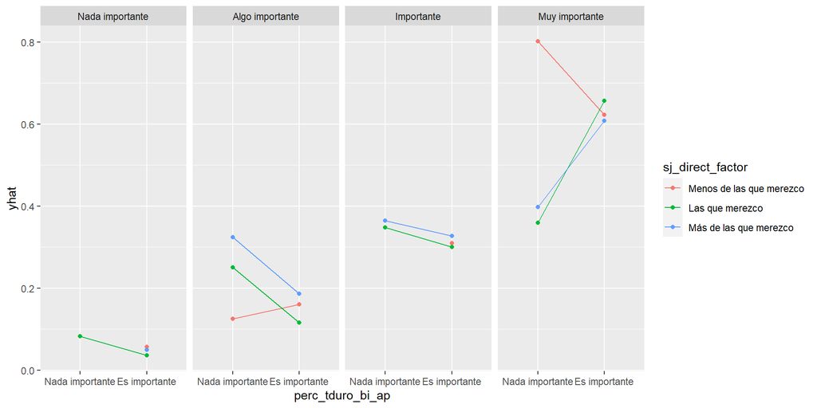

# Bibliografía

Dhar, Diva, Tarun Jain, and Seema Jayachandran. 2019. “Intergenerational Transmission of Gender Attitudes: Evidence from India.” *The Journal of Development Studies* 55 (12): 2572–92. https://doi.org/10.1080/00220388.2018.1520214.

Kunovich, S., and K. M. Slomczynski. 2007. “Systems of Distribution and a Sense of Equity: A Multilevel Analysis of Meritocratic Attitudes in Post-Industrial Societies.” *European Sociological Review* 23 (5): 649–63. https://doi.org/10.1093/esr/jcm026.

Resh, Nura. 2010. “Sense of Justice About Grades in School: Is It Stratified Like Academic Achievement?” *Social Psychology of Education* 13 (3): 313–29. https://doi.org/10.1007/s11218-010-9117-z.

Tam, Kim-Pong. 2015. “Understanding Intergenerational Cultural Transmission Through the Role of Perceived Norms.” *Journal of Cross-Cultural Psychology* 46 (10): 1260–6. https://doi.org/10.1177/0022022115600074.